# Get Started with rbbnp

## Overview

The **rbbnp** package implements a novel bias-bound approach to nonparametric inference developed by [Schennach (2020)](https://doi.org/10.1093/restud/rdz065). The key insight is that while we cannot consistently estimate pointwise bias, we can estimate an upper bound on bias magnitude, enabling valid confidence intervals with optimal bandwidths.

### The Problem

Traditional nonparametric inference faces a dilemma:

- **Optimal bandwidths** minimize mean squared error but introduce non-negligible bias
- **Undersmoothing** reduces bias but produces inefficient, wider confidence intervals

### The Solution

The bias-bound approach constructs confidence intervals that explicitly account for potential bias:

$$CI = [\hat{f} - \bar{b} -
z_{\alpha/2}\hat{\sigma}, \quad \hat{f} + \bar{b} +
z_{\alpha/2}\hat{\sigma}]$$

where $\bar{b}$ is the estimated bias bound.

## Installation

```r
# Install from CRAN
install.packages("rbbnp")

# Or install development version from GitHub
# install.packages("devtools")
devtools::install_github("xinyu-daidai/rbbnp-dev")
```

## Quick Start

### Density Estimation

```r
# Generate sample data
X <- gen_sample_data(size = 500, dgp = "2_fold_uniform", seed = 123456)

# Estimate density with bias-aware confidence intervals
fit <- biasBound_density(X, h = 0.1, kernel.fun = "Schennach2004")

# View summary
fit
```

```
#> Bias-Bounded Density Estimation
#>
#> Call:
#> biasBound_density(X = X, h = 0.1, kernel.fun = "Schennach2004")
#>
#> Sample size: n = 500
#> Bandwidth:   h = 0.1000 (user-specified)
#> Kernel:      Schennach2004
#>
#> Bias bound parameters:
#>   A = 6.3312, r = 2.3422
#>   bias bound b1x = 0.0714
#>
#> Evaluation points: 100 (range: [-0.1639, 2.0517])
#> Confidence level: 95%
#>
#> Use summary() for detailed statistics
#> Use plot() to visualize results
```

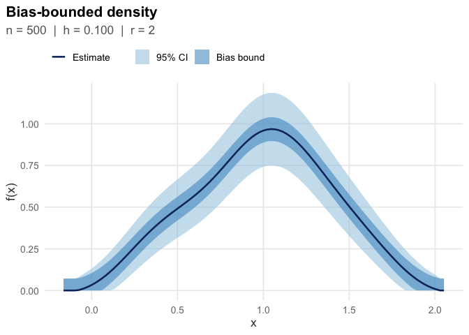

```r
# Visualize results
plot(fit)
```

The plot shows (the legend labels each element):

- **Estimate**: the estimated density $\hat{f}(x)$
- **Bias bound**: the range where $E[\hat{f}]$ may lie
- **95% CI**: the confidence interval

### Conditional Expectation (Regression)

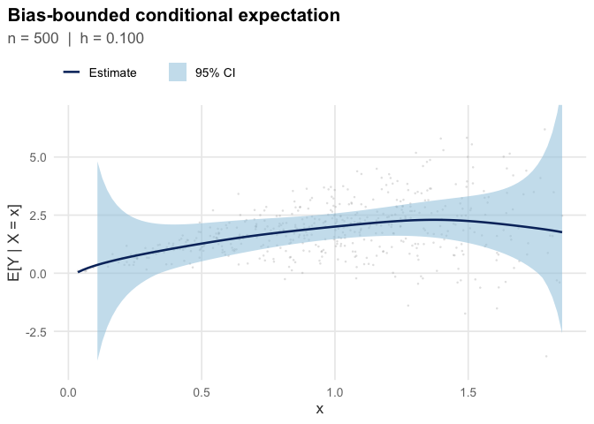

```r
# Generate regression data: Y = -X^2 + 3X + noise
Y <- -X^2 + 3*X + rnorm(500) * X

# Estimate conditional expectation
fit_reg <- biasBound_condExpectation(Y, X, h = 0.1, kernel.fun = "Schennach2004")

# Visualize
plot(fit_reg)
```

## Working with Results

Both functions return S3 objects with standard methods:

```r
# Extract parameters
coef(fit)
```

```
#>      A      r      h
#> 6.3312 2.3422 0.1000
```

```r
# Get confidence intervals
head(confint(fit))
```

```
#>      lower      upper
#> [1,]     0 0.07139636
#> [2,]     0 0.07139636
#> [3,]     0 0.07139636
#> [4,]     0 0.07139636
#> [5,]     0 0.08205420
#> [6,]     0 0.09605150
```

```r
# For regression: get fitted values
head(fitted(fit_reg))
```

```
#> [1] 0.0420927 0.1386661 0.2211023 0.2938845 0.3597238 0.4202832
```

## Next Steps

- **Density Estimation**: Detailed guide to density estimation
- **Regression**: Conditional expectation estimation
- **Theory**: Mathematical background

## References

Schennach, S. M. (2020). A Bias Bound Approach to Non-parametric Inference. *The Review of Economic Studies*, 87(5), 2439-2472. [doi:10.1093/restud/rdz065](https://doi.org/10.1093/restud/rdz065)